# Analysis of planAttributes.csv

Omar Besic und Musab Elkour

23 Mai 2019

Github Repository: https://github.com/besio1/bi_project

# Kontext

Das "Centers for Medicare & Medicaid Services (CMS) Center for Consumer Information & Insurance Oversight (CCIIO) veröffentlicht sogenannte Exchange PUFs, um Transparenz und Zugang über Qualified Health Plans (QHPs) und Stand-alone Dental Plans (SADPs) zu schaffen. Diese werden Einzelpersonen und Kleinunternehmen über die Krankenversicherungsbörse angeboten.

**Wir behandeln in diesem Bericht das “Planattribute” - PUF**

Der Planattribute - PUF enthält unter Anderem Daten über maximale Selbstbehalte oder“Health Savings Accounts” der amerikanischen Bürger. Diese werden anonym auf Bundesebene geteilt und durch die jeweiligen Herausgeber der Versicherungen erfasst.

# Vorgehensweise

1. Kontextanalyse der Daten
2. Kaggle Account erstellt + Daten extrahiert
3. Interessante Datensätze für die Auswertung herausgesucht | Use Case definiert
4. Gewählte Datensätze bereinigt
5. Bereinigte Datensätze manipuliert
6. Erstellen des Reports in RMarkdown

# Der Use Case

John Doe ist an Diabetes erkrankt. Die Dialysen im Spital kosten 35’000 Dollar pro Jahr. Sein Arbeitgeber (University of California) hat ihn und seine Familie mit einem “family plan” versichert.

Der **erste Selbstbehalt** beträgt 3’000 Dolar (sog. Deductible). Der **maximale Selbstbehalt** beträgt 15’000 Dollar. Nachdem der erste Selbstbehalt von 3’000 Dolar aufgebraucht wurde, trägt John und seine Familie 20% der versicherten Kosten selbst (**coinsurance**) und zwar solang bis der maximale Selbstbehalt von 15’000 Dollar pro Jahr erreicht wurde. Alle versicherten Leistungen über 15’000 Dollar werden von der Versicherungsgesellschaft übernommen.

1. Übersicht über die Begriffe
- Erste Selbstbehalt = Deductible
- Maximale Selbstbehalt = maximum out of pocket (moop)
- 20% Teilnahme an Kosten = coinsurance

John interessiert sich für die Gesamtsituation in den Vereinigten Staaten. Dazu hat er zwei Experten in R (Besic und Elkour) engagiert die ihn das Planattribute PUF genauer analysieren und veranschaulichen. Ihn interessiert vorallem die Selbstbehalte und die Coinsurance Rates in den einzelnen Bundesstaaten.

# Das Dataset

Insgesamt gibt es 179 Kolonnen. Untenstehend wird ein Ausschnitt der vorhandenen Kolonnen gezeigt. Die Rot markierten Zeilen (entspricht im planAttributes.csv den Spalten) werden in diesem Bericht eingehender analysiert.

| Ausschnitt der vorhandenen Spalten im planAttributes.csv x |
| --- |
| PlanType |
| QHPNonQHPTypeId |
| RowNumber |
| SBCHavingDiabetesCoinsurance |
| SBCHavingDiabetesCopayment |
| TEHBDedOutOfNetFamily |
| TEHBDedOutOfNetFamilyPerGroup |
| TEHBDedOutOfNetFamilyPerPerson |
| TEHBDedOutOfNetIndividual |
| TEHBInnTier1FamilyMOOP |
| TEHBInnTier1FamilyPerGroupMOOP |
| TEHBInnTier1FamilyPerPersonMOOP |
| TEHBInnTier1IndividualMOOP |
| TEHBInnTier2FamilyMOOP |

# TEHBInnTier1FamilyMOOP

Der “TEHBInnTier1FamilyMOOP” ist der maximale Selbstbehalt (maximum out of pocket) den man im Rahmen des Gesundheitsplans für eine Familie zahlt. Wir werden diese Kennzahl genauer analysieren.

1. Dazu müssen wir die Kolonne “TEHBInnTier1FamilyMOOP” bereinigen:
- Alle “,” in den Zellen entfernen
- Alle Dollarzeichen entfernen
- Alle nicht nummerischen Werte in nummerische Umwandeln
- Allen nummerischen Werte als 0 deklarieren

### Verteilung TEHBInnTier1FamilyMOOP

Wir generieren ein Histogramm. Merken aber, dass das Histogramm durch die zu vielen 0 Werte verzerrt wird. Deshalb entfernen wir 0 Werte, um einen besser lesbares Histogramm zu erhalten.

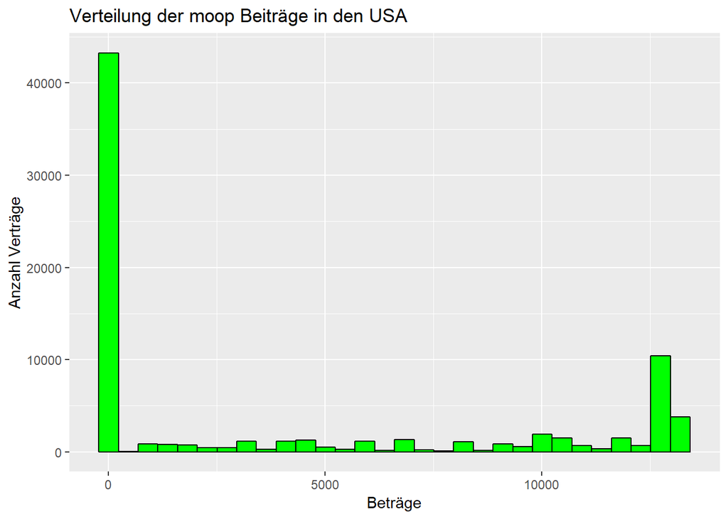

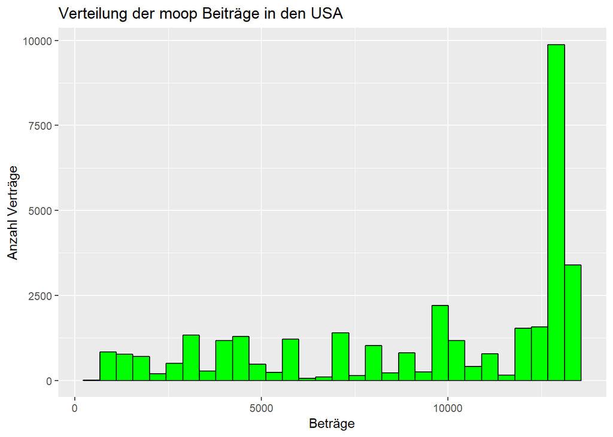

### Interaktive Darstellung der durchschn. TEHBInnTier1FamilyMOOP pro State

Nun zeigen wir die Verteilung der moop Beiträge auf die verschiedenen US Bundesstaaten verteilt.

[interactive chart not shown]

# SBCHavingDiabetesCoinsurance

Die “SBCHavingDiabetesCoinsurance” sind die Deckungskosten der Mitversicherung für das SBC Scenario für Diabetes.

SBC (Summary of Benefits and Coverage): Zusammenfassung der Leistungen und Deckung. Liefert klare und konsistente Informationen, um zu verstehen, was abgedeckt ist und was es kostet.

Wir werden diese Kennzahl genauer analysieren.

1. Dazu müssen wir die Kolonne “SBCHavingDiabetesCoinsurance” bereinigen:
- Alle “,” in den Zellen entfernen
- Alle Dollarzeichen entfernen
- Alle nicht nummerischen Werte in nummerische Umwandeln
- Allen nummerischen Werte als 0 deklarieren

### Verteilung SBCHavingDiabetesCoinsurance

Wir generieren ein Barplot und ein Histogramm. Merken aber, dass beide Diagramme durch die zu vielen 0 Werte verzerrt wird. Hier wurde nur das Jahr 2014 analysiert und betrachtet. Deshalb entfernen wir die 0 Werte, um besser lesbare Diagramme zu erhalten.

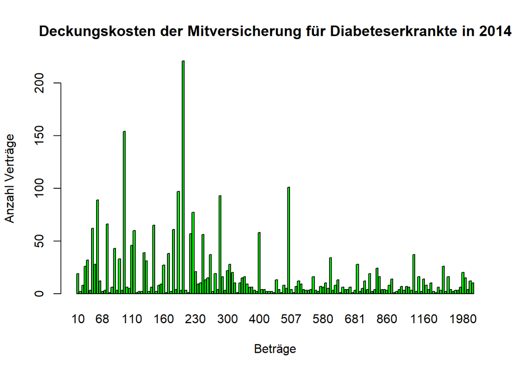

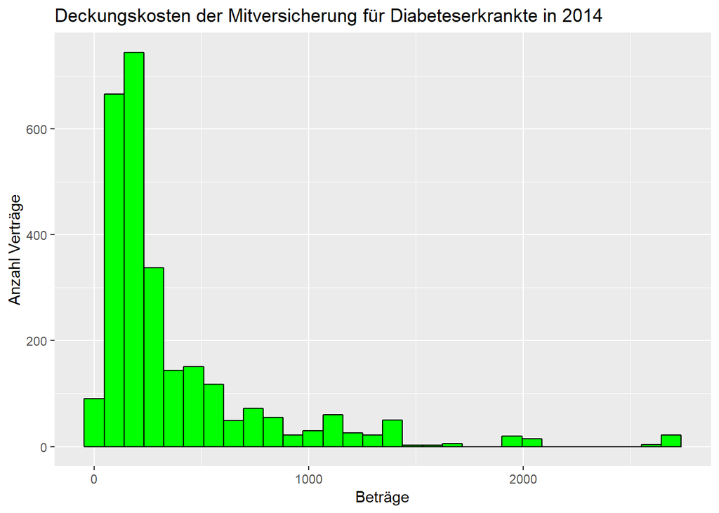

### Tabellarische Liste der durchschnittlichen SBCHavingDiabetesCoinsurance pro State

Hier haben wir die Liste aller StateCodes sowie die Durchschnittsdeckungskosten je Staat aufgelistet und zusammengefasst. Dies wird benötigt für die MAP Darstellung der Deckungskostenverteilung.

```
##    state coinsurance
## 1     AK    199.6970
## 2     AL    240.0000
## 3     AR    408.9189
## 4     AZ    272.2222
## 5     DE    200.0000
## 6     FL    285.2077
## 7     GA    198.3582
## 8     IA     73.7500
## 9     ID    660.5000
## 10    IL    120.6897
## 11    IN    226.5109
## 12    KS   1361.6129
## 13    LA    334.1905
## 14    ME    432.2667
```

[output cut: 18 more lines]

### Interaktive Darstellung der durchschn. SBCHavingDiabetesCoinsurance pro State

Nun zeigen wir die Verteilung der Deckungskosten auf die verschiedenen US Bundesstaaten verteilt für das Jahr 2014 (mit Informationsfenster für jede Staat über die Deckungskosten sowie Staatsname und Businessyear).

[interactive chart not shown]